# Exam 1 Code

Trelan Hakkem-Barron

2/7/2020

# Question 1

By looking at the code below, there seems to be a continuous negative linear trend going on. This appears to be a seasonal trend but it is not a clear pattern based on the data being on a complete fixed frequency.

```r
library(TSA)
library(tseries)
library(forecast)
```

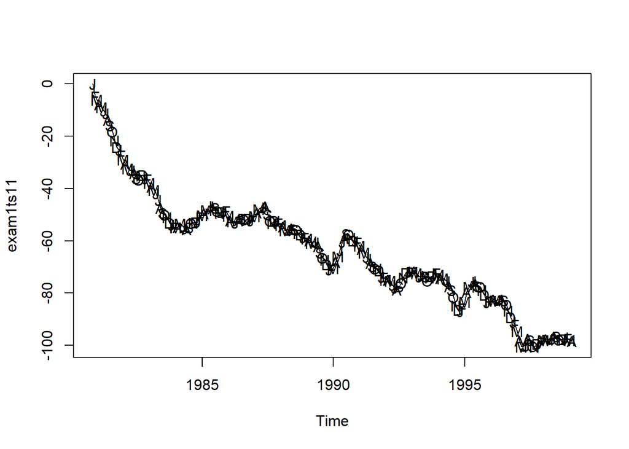

```r
load(url("http://goo.gl/nGgyoh"))
months <- c("J", "F", "M", "A", "M", "J", "J", "A", "S", "O", "N", "D")
plot(exam1ts11)
points(exam1ts11, pch=months)
```

## Question 1 B)

exam1ts11 The period for this time series is from 1981 to 1999. It does appear that this data has a more cyclic pattern going on. The cyclic variation decreases over time.

By using the Dickey-Fuller Test, we are able to conclude that this time series is indeed stationary

```r
adf.test(exam1ts11, k=0)
```

```
##
##  Augmented Dickey-Fuller Test
##
## data:  exam1ts11
## Dickey-Fuller = -4.4814, Lag order = 0, p-value = 0.01
## alternative hypothesis: stationary
```

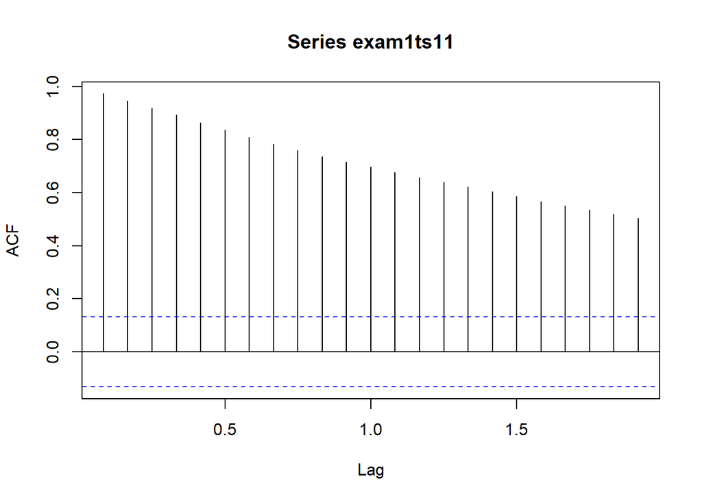

```r
acf(exam1ts11)
```

# Question 2

So here the estimated slope and intercept are B1 = -3.92862 and B0 = 7754.67728, respectively.

```r
model1=lm(exam1ts11~time(exam1ts11))
summary(model1)
```

```
##
## Call:
## lm(formula = exam1ts11 ~ time(exam1ts11))
##
## Residuals:
##      Min       1Q   Median       3Q      Max
## -15.4448  -3.4544  -0.0898   3.5513  27.2704
##
## Coefficients:
##                   Estimate Std. Error t value Pr(>|t|)
## (Intercept)     7754.67728  173.20424   44.77   <2e-16 ***
## time(exam1ts11)   -3.92862    0.08704  -45.14   <2e-16 ***
## ---
## Signif. codes:  0 '***' 0.001 '**' 0.01 '*' 0.05 '.' 0.1 ' ' 1
##
## Residual standard error: 6.832 on 218 degrees of freedom
## Multiple R-squared:  0.9033, Adjusted R-squared:  0.9029
## F-statistic:  2037 on 1 and 218 DF,  p-value: < 2.2e-16
```

# Question 3

For both of the parameters, the p value is 2e-16. We are able to reject the null hypothesis because the p value passes the significance test for 0.10, 0.05, 0.01, and 0.001.We have a nice model for this time series. Our adjusted R squared also has a value of 0.9029.

# Question 4

This graph gives us a slightly better insight as to what is going on. It is showing that the declines are happening in various intervals. This could be business data.

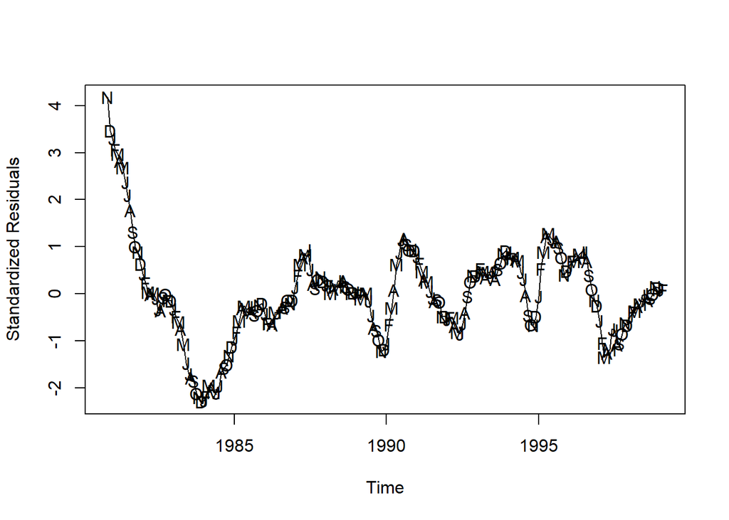

```r
plot(y=rstudent(model1),x=as.vector(time(exam1ts11)),xlab='Time',
      ylab='Standardized Residuals',type='l')
 points(y=rstudent(model1),x=as.vector(time(exam1ts11)),
         pch=as.vector(season(exam1ts11)))
```